# Actividad 1.1 Normalidad univariada. Transformaciones para normalidad_A01709445

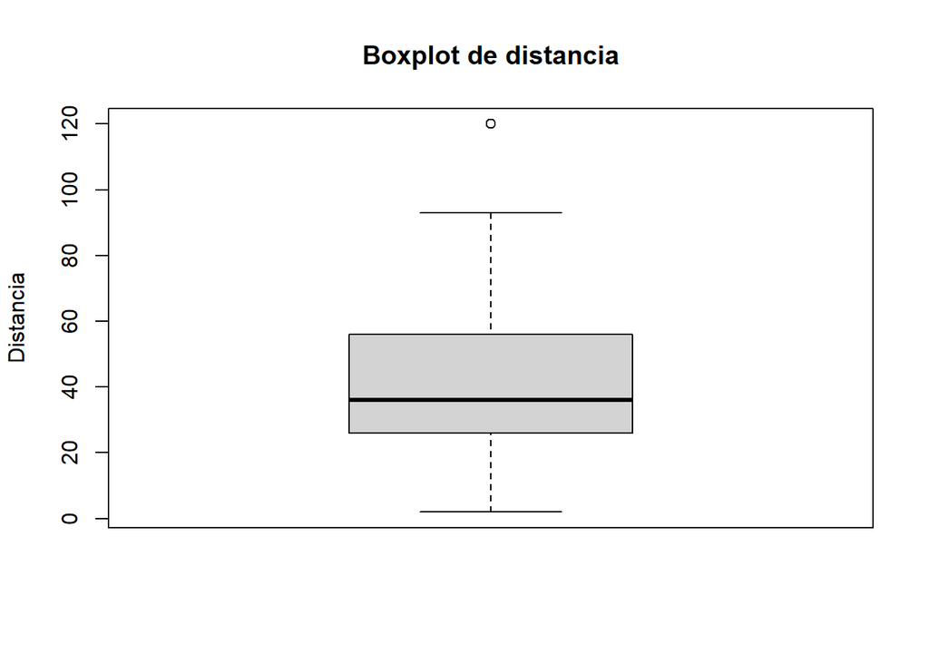

```r
# Distance
boxplot(cars$dist,
        main = "Boxplot de distancia",
        ylab = "Distancia")
```

En el histograma de la velocidad se puede observar la similitud de ambas funciones. La función de la velocidad esta un poco más plana que la normal teorica lo que concuerda con la curtosis un poco más bajo de 3 aunque igual esta muy cerca. Igualmente se puede observar como los datos estan muy ligeramente cargados a la derecha lo que también corresponde con el sesgo negativo calculado anteriormente. Por otro lado la función de la distancia se puede ver como esta sesgada a la derecha ya que los datos se concentran más en el extremo izquierdo, ademas también se puede ver como la función alcanza un pico más alto a comparación de la distribución normal lo que igual corresponde con la curtosis calculada de 3.24.

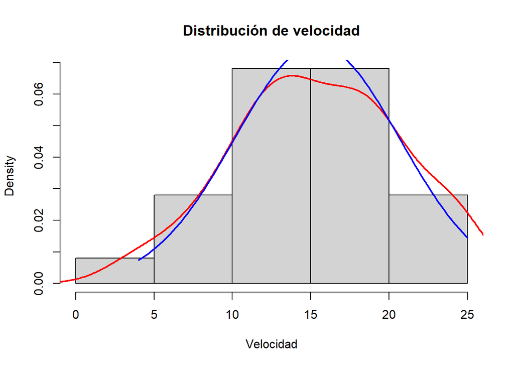

```r
# Histograma, densidad empírica y normal teórica

# Speed
hist(cars$speed,
     freq = FALSE,
     main = "Distribución de velocidad",
     xlab = "Velocidad")

lines(density(cars$speed),
      col = "red",
      lwd = 2)

curve(dnorm(x,
            mean = mean(cars$speed),
            sd = sd(cars$speed)),
      from = min(cars$speed),
      to = max(cars$speed),
      add = TRUE,
      col = "blue",
      lwd = 2)
```

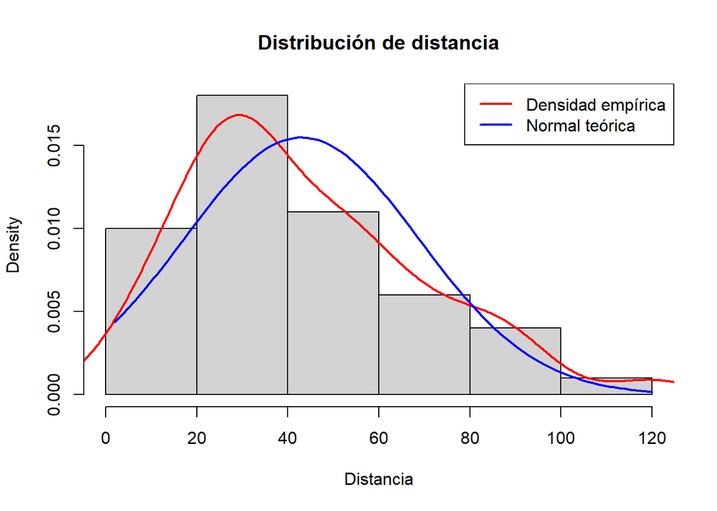

```r
# Distance
hist(cars$dist,
     freq = FALSE,
     main = "Distribución de distancia",
     xlab = "Distancia")

lines(density(cars$dist),
      col = "red",
      lwd = 2)

curve(dnorm(x,
            mean = mean(cars$dist),
            sd = sd(cars$dist)),
      from = min(cars$dist),
      to = max(cars$dist),
      add = TRUE,
      col = "blue",
      lwd = 2)

legend("topright",
       legend = c("Densidad empírica", "Normal teórica"),
       col = c("red", "blue"),
       lwd = 2)
```

Se utilizó IA de la siguiente forma: Herramienta: ChatGPT Uso realizado: Hacer más vizuales los diagramas Secciones donde se utilizó: Sesgo y curtosis en la Normalidad y fuera de ella, parte 2 Validación realizada por los estudiantes: Verifique que la información fuera consistente Todo el contenido fue revisado